# PracticalMachineLearning-Course Project

Suvojyoti Chowdhury

March 15, 2016

## Background

Using devices such as Jawbone Up, Nike FuelBand, and Fitbit it is now possible to collect a large amount of data about personal activity relatively inexpensively. These type of devices are part of the quantified self movement of a group of enthusiasts who take measurements about themselves regularly to improve their health, to find patterns in their behavior, or because they are tech geeks. One thing that people regularly do is quantify how much of a particular activity they do, but they rarely quantify how well they do it. In this project, your goal will be to use data from accelerometers on the belt, forearm, arm, and dumbell of 6 participants. They were asked to perform barbell lifts correctly and incorrectly in 5 different ways. More information is available from the website here: http://groupware.les.inf.puc-rio.br/har (see the section on the Weight Lifting Exercise Dataset).

## Course Project Objective

The experiment was performed with different subjects and they all were asked to do some specific activity. In order to perform the activity, it is suggested to do it in a specific way. If it is not done in that way, it would give wrong result.

This is the submitted project for evaluation of different machine learning techniques and finally predict that the manner in which a participent has performed an exercise, whether that is correct or wrong, depending on the accelerometer

## Overview of approach

Upon analyzing the training data set, the following things are observed: 1. The data set had 159 predictors 2. There are a large number of NA 3. There are “divided by zero” exceptions for many observations

So my approach was first to clean the dataset, reduce number of predictors and then apply machine learning algorithms

For selecting algorithms, as per general tendency for these type of multiclass outome problem, I started with Decision Trees

## Coding Section

### Loading Packages

```r
# Loading required libraries
library(ggplot2)
library(caret)
library(rpart)
library(rpart.plot)
library(RColorBrewer)
library(rattle)
library(corrplot)
library(randomForest)
library(plyr)
library(dplyr)
library(doMC)
```

### Data Loading

```r
# Data Loading
#-------------
# trainUrl <- "http://d396qusza40orc.cloudfront.net/predmachlearn/pml-training.csv"
# testUrl <- "http://d396qusza40orc.cloudfront.net/predmachlearn/pml-testing.csv"
# Loading the data

# download.file(trainUrl,destfile = "pml_train.csv")
# download.file(testUrl,destfile = "pml_test.csv")
training <- read.csv("pml_train.csv", na.strings=c("NA","#DIV/0!",""))
testing <- read.csv("pml_test.csv", na.strings=c("NA","#DIV/0!",""))
```

### Removing columns with large amount of NA values

There are many columns which have good amount of NA values These would be problem for modelling So I decide to remove those columns where NA values are more than 60% of records

```r
# Create function to tell whether a list is having
# more than 60% NAs

colNA<- function(x) {
  ifelse(sum(is.na(x))/length(x) > .6,T,F)
}
# Apply the function to training set
colMostNA<-apply(training,2,colNA)
table(colMostNA)
```

```
## colMostNA
## FALSE  TRUE
##    60   100
```

```r
# Extract data with less NA columns
train_Clean<-training[,!colMostNA]
dim(train_Clean)
```

```
## [1] 19622    60
```

```r
# clean testdataset variables also
dim(testing)
```

```
## [1]  20 160
```

```r
test_clean<-testing[,!colMostNA]
dim(test_clean)
```

```
## [1] 20 60
```

### Next, we check the near zero variables

```r
nearZero <- nearZeroVar(train_Clean, saveMetrics=TRUE)
```

Only except “new_window”, all other are having ample variation

We also obsereved that the variables X and username should not have any impact on the outcome, so removing those and the newwindow

```r
train_ds<-train_Clean[,-c(1,2,6)]

test_ds<-test_clean[,-c(1,2,6)]
```

### Data Partitioning

The test set given for this assignment is small, with 20 observations only. So I would create a partition in the training set with 75:25 proportion, first set to be used for training, the second set would be kept for testing.

```r
set.seed(6666)
inTrain = createDataPartition(train_ds$classe, p = 3/4)[[1]]
train = train_ds[ inTrain,]
hold = train_ds[-inTrain,]
```

### First fit decission tree

[figure not shown]

```r
dtMod <- rpart(classe ~ ., data=train, method="class")
fancyRpartPlot(dtMod,palettes=c("Greys", "Oranges"))
```

### In Sample error rate

```r
dtTrain<-predict(dtMod,train,type="class")
confusionMatrix(dtTrain, train$classe)
```

```
## Confusion Matrix and Statistics
##
##           Reference
## Prediction    A    B    C    D    E
##          A 4036  111   12    5    0
##          B  118 2486  259  124    0
##          C   31  232 2256  369   96
##          D    0   19   29 1696  166
##          E    0    0   11  218 2444
##
## Overall Statistics
##
##                Accuracy : 0.8777
##                  95% CI : (0.8723, 0.883)
##     No Information Rate : 0.2843
##     P-Value [Acc > NIR] : < 2.2e-16
##
##                   Kappa : 0.8452
##  Mcnemar's Test P-Value : NA
##
## Statistics by Class:
##
##                      Class: A Class: B Class: C Class: D Class: E
## Sensitivity            0.9644   0.8729   0.8788   0.7032   0.9032
## Specificity            0.9878   0.9578   0.9401   0.9826   0.9809
## Pos Pred Value         0.9693   0.8323   0.7560   0.8880   0.9143
## Neg Pred Value         0.9859   0.9691   0.9735   0.9441   0.9782
## Prevalence             0.2843   0.1935   0.1744   0.1639   0.1839
## Detection Rate         0.2742   0.1689   0.1533   0.1152   0.1661
## Detection Prevalence   0.2829   0.2029   0.2027   0.1298   0.1816
## Balanced Accuracy      0.9761   0.9153   0.9095   0.8429   0.9421
```

### Check the out-of sample performance

```r
dtPred <- predict(dtMod,hold, type = "class")
# Check Performance
confusionMatrix(dtPred, hold$classe)
```

```
## Confusion Matrix and Statistics
##
##           Reference
## Prediction    A    B    C    D    E
##          A 1344   48    5    1    0
##          B   43  817   97   43    0
##          C    8   80  735  115   44
##          D    0    4   10  571   74
##          E    0    0    8   74  783
##
## Overall Statistics
##
##                Accuracy : 0.8666
##                  95% CI : (0.8568, 0.876)
##     No Information Rate : 0.2845
##     P-Value [Acc > NIR] : < 2.2e-16
##
##                   Kappa : 0.8312
##  Mcnemar's Test P-Value : NA
##
## Statistics by Class:
##
##                      Class: A Class: B Class: C Class: D Class: E
## Sensitivity            0.9634   0.8609   0.8596   0.7102   0.8690
## Specificity            0.9846   0.9537   0.9390   0.9785   0.9795
## Pos Pred Value         0.9614   0.8170   0.7485   0.8665   0.9052
## Neg Pred Value         0.9855   0.9662   0.9694   0.9451   0.9708
## Prevalence             0.2845   0.1935   0.1743   0.1639   0.1837
## Detection Rate         0.2741   0.1666   0.1499   0.1164   0.1597
## Detection Prevalence   0.2851   0.2039   0.2002   0.1344   0.1764
## Balanced Accuracy      0.9740   0.9073   0.8993   0.8444   0.9243
```

So we observe that out of sample accuracy is around 86.7%.

Now we will try to deep dive into the attributes once again and swill see if we can improve the performance

### Remove Highly correlated coefficients

We check if there are predictors which are highly correlated among themselves. If we found many of such, we would drop the correlators, selecting by findCorrelation function

```r
# Change factors to numbers for correlation plot
train$raw_timestamp_part_1<-as.numeric(train$raw_timestamp_part_1)
train$cvtd_timestamp<-as.numeric(train$cvtd_timestamp)
# Find predictors having correlation of .75 or higher with other predictors, but having higher average correlation with other predictors
highCorr<-findCorrelation(cor(train[,-57]),cutoff = .75)
length(highCorr)
```

```
## [1] 20
```

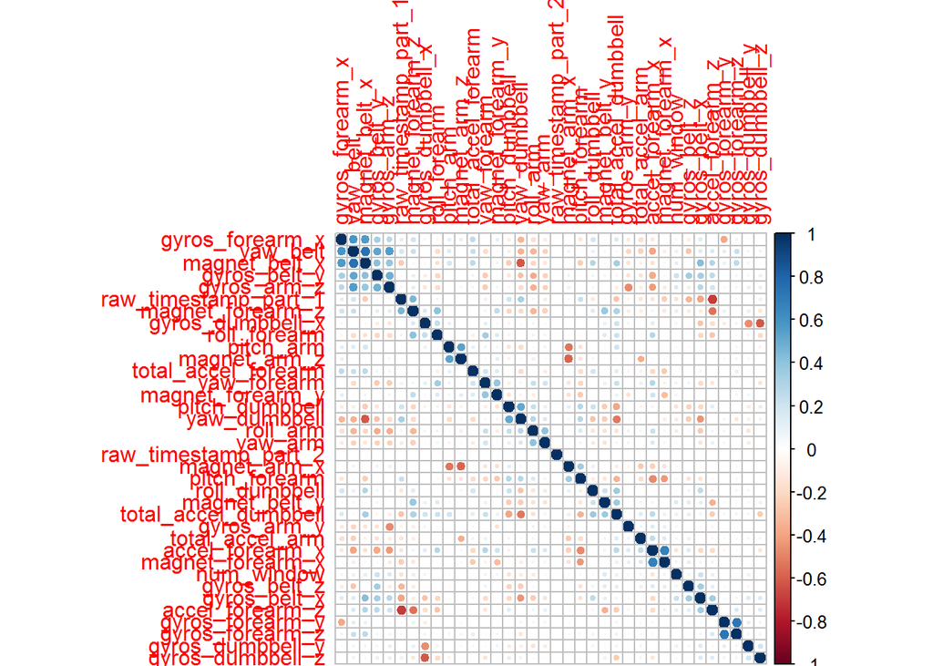

```r
trainDF<-train[,-highCorr]
corrplot(cor(trainDF[,-37],use="complete.obs"),order="hclust")
```

```r
holdDF<-hold[,-highCorr]
testDF<-test_ds[,-highCorr]
```

### Random Forest Model

Now we try to train our training data with random forest model.

### Processing time issue

Upon trying random forest, we observed that it is taking much amount of time(in hours) to train the dataset. Then as per suggestion of “Ray Jones”, I tried to control the processing by using multiple processor threads and assigning specific number of variables to each node of the trees of RF

```r
#  install.packages("doMC", repos="http://R-Forge.R-project.org")
set.seed(666)
registerDoMC(cores=4)
mtryGrid <- expand.grid(mtry = 10)
ctrl<-trainControl(allowParallel=T)

# Train random forest
rfMod <- train(classe~.,data=trainDF,
               method="rf",
               trControl=ctrl,
               tuneGrid=mtryGrid,
               ntree=100
               )
```

### In Sample error rate

```r
rfTrain<-predict(rfMod,trainDF)
confusionMatrix(rfTrain, trainDF$classe)
```

```
## Confusion Matrix and Statistics
##
##           Reference
## Prediction    A    B    C    D    E
##          A 4185    0    0    0    0
##          B    0 2848    0    0    0
##          C    0    0 2567    0    0
##          D    0    0    0 2412    0
##          E    0    0    0    0 2706
##
## Overall Statistics
##
##                Accuracy : 1
##                  95% CI : (0.9997, 1)
##     No Information Rate : 0.2843
##     P-Value [Acc > NIR] : < 2.2e-16
##
##                   Kappa : 1
##  Mcnemar's Test P-Value : NA
##
## Statistics by Class:
##
##                      Class: A Class: B Class: C Class: D Class: E
## Sensitivity            1.0000   1.0000   1.0000   1.0000   1.0000
## Specificity            1.0000   1.0000   1.0000   1.0000   1.0000
## Pos Pred Value         1.0000   1.0000   1.0000   1.0000   1.0000
## Neg Pred Value         1.0000   1.0000   1.0000   1.0000   1.0000
## Prevalence             0.2843   0.1935   0.1744   0.1639   0.1839
## Detection Rate         0.2843   0.1935   0.1744   0.1639   0.1839
## Detection Prevalence   0.2843   0.1935   0.1744   0.1639   0.1839
## Balanced Accuracy      1.0000   1.0000   1.0000   1.0000   1.0000
```

### Out of sample error rate

```r
rfPred<-predict(rfMod,holdDF)
confusionMatrix(rfPred,holdDF$classe)
```

```
## Confusion Matrix and Statistics
##
##           Reference
## Prediction    A    B    C    D    E
##          A 1395    0    0    0    0
##          B    0  949    0    0    0
##          C    0    0  855    1    0
##          D    0    0    0  803    1
##          E    0    0    0    0  900
##
## Overall Statistics
##
##                Accuracy : 0.9996
##                  95% CI : (0.9985, 1)
##     No Information Rate : 0.2845
##     P-Value [Acc > NIR] : < 2.2e-16
##
##                   Kappa : 0.9995
##  Mcnemar's Test P-Value : NA
##
## Statistics by Class:
##
##                      Class: A Class: B Class: C Class: D Class: E
## Sensitivity            1.0000   1.0000   1.0000   0.9988   0.9989
## Specificity            1.0000   1.0000   0.9998   0.9998   1.0000
## Pos Pred Value         1.0000   1.0000   0.9988   0.9988   1.0000
## Neg Pred Value         1.0000   1.0000   1.0000   0.9998   0.9998
## Prevalence             0.2845   0.1935   0.1743   0.1639   0.1837
## Detection Rate         0.2845   0.1935   0.1743   0.1637   0.1835
## Detection Prevalence   0.2845   0.1935   0.1746   0.1639   0.1835
## Balanced Accuracy      1.0000   1.0000   0.9999   0.9993   0.9994
```

### Plot the hold set predictions

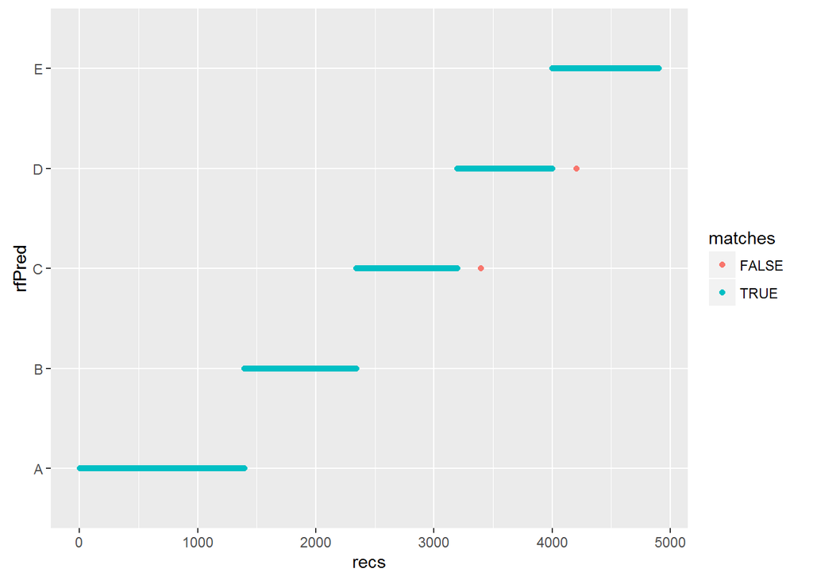

```r
recs<-1:length(rfPred)
plotDF<-data.frame(recs,rfPred)
matches<-rfPred==holdDF$classe
qplot(recs,rfPred,data=plotDF,color=matches)
```

### So we got out of sample accuracy of 99.96% with the random forest model

### Applying model on the test set

```r
resultPred<-predict(rfMod,testDF)

resultPred
```

```
##  [1] B A B A A E D B A A B C B A E E A B B B
## Levels: A B C D E
```